# データ分析と線形代数06

UPDATE: 2022-10-28 20:13:11

# 線形代数とデータ分析

線形代数のおらさいメモ。[Qiita](https://qiita.com/wasabayes/private/ef81b2d38dde0cc79e4f)にも、データ分析に必要な線形代数のおさらい記事を投稿しました。

## 共分散行列

変数同士の分散と共分散を行列としてまとめた行列。

```r
library(mvtnorm)
library(tidyverse)

#行列
A <- matrix(c(1,1,2,1,1,3,4,4,2,1,
              3,2,3,2,2,4,1,4,3,2,
              1,1,1,2,2,1,2,1,2,2,
              1,3,1,1,2,1,3,2,4,1,
              4,1,1,1,3,3,4,4,2,4,
              5,3,5,5,2,5,4,4,4,1,
              26,22,27,34,28,20,18,30,23,32), 10, 7)
```

```r
#偏差行列
AA <- sweep(A, 2, apply(A, 2, mean))
AA
```

```
##       [,1] [,2] [,3] [,4] [,5] [,6] [,7]
##  [1,]   -1  0.4 -0.5 -0.9  1.3  1.2    0
##  [2,]   -1 -0.6 -0.5  1.1 -1.7 -0.8   -4
##  [3,]    0  0.4 -0.5 -0.9 -1.7  1.2    1
##  [4,]   -1 -0.6  0.5 -0.9 -1.7  1.2    8
##  [5,]   -1 -0.6  0.5  0.1  0.3 -1.8    2
##  [6,]    1  1.4 -0.5 -0.9  0.3  1.2   -6
##  [7,]    2 -1.6  0.5  1.1  1.3  0.2   -8
##  [8,]    2  1.4 -0.5  0.1  1.3  0.2    4
##  [9,]    0  0.4  0.5  2.1 -0.7  0.2   -3
## [10,]   -1 -0.6  0.5 -0.9  1.3 -2.8    6
```

「偏差行列を転置した行列」と「偏差行列」を掛け合わせると、分散をN倍した行列となる。

```r
#n倍のt(偏差行列)*偏差行列
t(AA) %*% AA
```

```
##      [,1] [,2] [,3]  [,4] [,5]  [,6] [,7]
## [1,]   14  3.0 -1.0   3.0  6.0   5.0  -26
## [2,]    3  8.4 -3.0  -2.4  0.8   5.2    2
## [3,]   -1 -3.0  2.5   1.5  0.5  -3.0    5
## [4,]    3 -2.4  1.5  10.9 -1.3  -2.2  -27
## [5,]    6  0.8  0.5  -1.3 16.1  -4.6   -5
## [6,]    5  5.2 -3.0  -2.2 -4.6  17.6  -15
## [7,]  -26  2.0  5.0 -27.0 -5.0 -15.0  246
```

```r
#共分散行列に戻すためにn-1(不偏分散)で割る
cov_mat <- (t(AA)  %*% AA)/(nrow(A)-1)
round(cov_mat,2)
```

```
##       [,1]  [,2]  [,3]  [,4]  [,5]  [,6]  [,7]
## [1,]  1.56  0.33 -0.11  0.33  0.67  0.56 -2.89
## [2,]  0.33  0.93 -0.33 -0.27  0.09  0.58  0.22
## [3,] -0.11 -0.33  0.28  0.17  0.06 -0.33  0.56
## [4,]  0.33 -0.27  0.17  1.21 -0.14 -0.24 -3.00
## [5,]  0.67  0.09  0.06 -0.14  1.79 -0.51 -0.56
## [6,]  0.56  0.58 -0.33 -0.24 -0.51  1.96 -1.67
## [7,] -2.89  0.22  0.56 -3.00 -0.56 -1.67 27.33
```

```r
round(cov(A),2)
```

```
##       [,1]  [,2]  [,3]  [,4]  [,5]  [,6]  [,7]
## [1,]  1.56  0.33 -0.11  0.33  0.67  0.56 -2.89
## [2,]  0.33  0.93 -0.33 -0.27  0.09  0.58  0.22
## [3,] -0.11 -0.33  0.28  0.17  0.06 -0.33  0.56
## [4,]  0.33 -0.27  0.17  1.21 -0.14 -0.24 -3.00
## [5,]  0.67  0.09  0.06 -0.14  1.79 -0.51 -0.56
## [6,]  0.56  0.58 -0.33 -0.24 -0.51  1.96 -1.67
## [7,] -2.89  0.22  0.56 -3.00 -0.56 -1.67 27.33
```

共分散行列から相関行列に変換するために標準偏差の対角行列を用いて変換する。

```r
cor_mat <- sqrt(diag(1/diag(cov_mat))) %*% cov_mat%*% sqrt(diag(1/diag(cov_mat)))
round(cor_mat,2)
```

```
##       [,1]  [,2]  [,3]  [,4]  [,5]  [,6]  [,7]
## [1,]  1.00  0.28 -0.17  0.24  0.40  0.32 -0.44
## [2,]  0.28  1.00 -0.65 -0.25  0.07  0.43  0.04
## [3,] -0.17 -0.65  1.00  0.29  0.08 -0.45  0.20
## [4,]  0.24 -0.25  0.29  1.00 -0.10 -0.16 -0.52
## [5,]  0.40  0.07  0.08 -0.10  1.00 -0.27 -0.08
## [6,]  0.32  0.43 -0.45 -0.16 -0.27  1.00 -0.23
## [7,] -0.44  0.04  0.20 -0.52 -0.08 -0.23  1.00
```

```r
round(cor(A),2)
```

```
##       [,1]  [,2]  [,3]  [,4]  [,5]  [,6]  [,7]
## [1,]  1.00  0.28 -0.17  0.24  0.40  0.32 -0.44
## [2,]  0.28  1.00 -0.65 -0.25  0.07  0.43  0.04
## [3,] -0.17 -0.65  1.00  0.29  0.08 -0.45  0.20
## [4,]  0.24 -0.25  0.29  1.00 -0.10 -0.16 -0.52
## [5,]  0.40  0.07  0.08 -0.10  1.00 -0.27 -0.08
## [6,]  0.32  0.43 -0.45 -0.16 -0.27  1.00 -0.23
## [7,] -0.44  0.04  0.20 -0.52 -0.08 -0.23  1.00
```

逆のパターン。相関行列から共分散行列。

```r
#相関行列→共分散行列
diag_mat <- diag(apply(A, 2, sd)) #SDが対角成分にある対角行列
cov_mat2 <- diag_mat %*% cor_mat %*% diag_mat
round(cov_mat2,2)
```

```
##       [,1]  [,2]  [,3]  [,4]  [,5]  [,6]  [,7]
## [1,]  1.56  0.33 -0.11  0.33  0.67  0.56 -2.89
## [2,]  0.33  0.93 -0.33 -0.27  0.09  0.58  0.22
## [3,] -0.11 -0.33  0.28  0.17  0.06 -0.33  0.56
## [4,]  0.33 -0.27  0.17  1.21 -0.14 -0.24 -3.00
## [5,]  0.67  0.09  0.06 -0.14  1.79 -0.51 -0.56
## [6,]  0.56  0.58 -0.33 -0.24 -0.51  1.96 -1.67
## [7,] -2.89  0.22  0.56 -3.00 -0.56 -1.67 27.33
```

## 線形写像

表現行列をベクトルにかけることでベクトルを写す。下記では、ベクトルを45°回転させる。

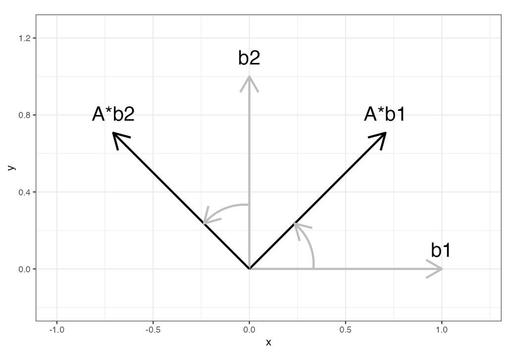

```r
#45°回転させる表現行列
A = matrix(c(cos(pi/4), sin(pi/4), -sin(pi/4), cos(pi/4)),2,2)
B = matrix(c(1,0,0,1),2,2)
res <- A %*% B
xend1 <- B[1,1] ; yend1 <- B[2,1]
xend2 <- B[1,2] ; yend2 <- B[2,2]
res11 <- res[1,1] ; res21 <- res[2,1]
res12 <- res[1,2] ; res22 <- res[2,2]

ggplot() +
  geom_segment(aes(x = 0, y = 0, xend = xend1, yend = yend1),
               arrow = arrow(), col = "Gray", size = 1) +
  annotate("text", x = xend1, y = yend1+0.1, label = "b1", size = 7) +
  geom_segment(aes(x = 0, y = 0, xend = res11, yend = res21),
               arrow = arrow(), col = "Black", size = 1) +
  annotate("text", x = res11, y = res21+0.1, label = "A*b1", size = 7) +
  geom_curve(aes(x = xend1/3, y = yend1/3, xend = res11/3, yend = res21/3),
             arrow = arrow(), col = "Gray", size = 1, curvature = .25) +
  geom_segment(aes(x = 0, y = 0, xend = xend2, yend = yend2),
               arrow = arrow(), col = "Gray", size = 1) +
  annotate("text", x = xend2, y = yend2+0.1, label = "b2", size = 7) +
  geom_segment(aes(x = 0, y = 0, xend = res12, yend = res22),
               arrow = arrow(), col = "Black", size = 1) +
  annotate("text", x = res12, y = res22+0.1, label = "A*b2", size = 7) +
  geom_curve(aes(x = xend2/3, y = yend2/3, xend = res12/3, yend = res22/3),
             arrow = arrow(), col = "Gray", size = 1, curvature = .25) +
  coord_fixed(ratio = 1) +
  ylim(c(-0.2,1.25)) + xlim(c(-1, 1.2)) +
  theme_bw()
```

つまりこのように回転させている。

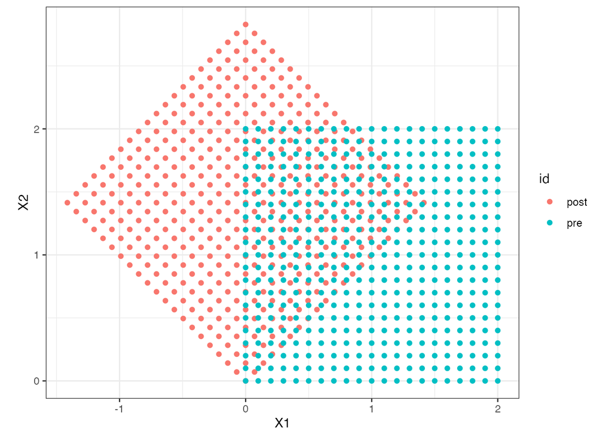

```r
linear_trans <- function(a, b, c, d){
  Represent <- matrix(c(a, b, c, d), nrow = 2, ncol = 2)
  data <- c()
  for (i in seq(0,2,0.1)){
    subdata <- c()
    for(j in seq(0,2,0.1)){
      Vec <- c(i, j)
      Mapping <- Represent %*% Vec
      temp <- c(Vec, Mapping)
      subdata <- rbind(subdata, temp)
    }
    data <- rbind(data, subdata)
  }
  return(data)
}

df <- linear_trans(cos(pi/4), sin(pi/4), -sin(pi/4), cos(pi/4)) #45°回転
pre  <- data.frame(df) %>% select(X1,X2) %>% mutate(id = "pre")
df <- data.frame(df) %>% select(X3,X4) %>% rename(X1 = X3, X2 = X4) %>% mutate(id = "post") %>% bind_rows(pre)

ggplot(df, aes(x = X1, y = X2, col = id)) +
  geom_point() +
  coord_fixed(ratio = 1) +
  theme_bw()
```

## 固有値と固有ベクトル

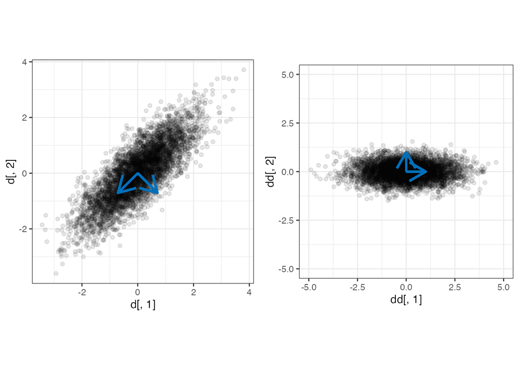

```r
library(mvtnorm)
library(gridExtra)
sig <- matrix(c(1,0.8,0.8,1), ncol = 2)
d <- rmvnorm(n = 5000, mean = c(0,0), sigma = sig)
d <- scale(d)

cov_mat <- cov(d[,1:2])
eig <- eigen(cov_mat)

c1 <- d %>%
  as_data_frame() %>%
  ggplot(., aes(d[,1], d[,2])) +
  geom_point(alpha = 0.1) +
  geom_segment(aes(x = 0, y = 0,
                   xend = eig$vectors[1,1], yend = eig$vectors[2,1]),
               arrow = arrow(), col = "#0070B9", size = 1) +
  geom_segment(aes(x = 0, y = 0,
                   xend = eig$vectors[1,2], yend = eig$vectors[2,2]),
               arrow = arrow(), col = "#0070B9", size = 1) +
  coord_fixed(ratio = 1) +
  theme_bw()

#固有値ベクトルで直交回転
dd <- d %*% eig$vectors

c2 <- dd %>%
  as_data_frame() %>%
  ggplot(., aes(dd[,1], dd[,2])) +
  geom_point(alpha = 0.1) +
  geom_segment(aes(x = 0, y = 0, xend = 1, yend = 0),
               arrow = arrow(), col = "#0070B9", size = 1) +
  geom_segment(aes(x = 0, y = 0, xend = 0, yend = 1),
               arrow = arrow(), col = "#0070B9", size = 1) +
  ylim(c(-5,5)) + xlim(c(-5,5)) + coord_fixed(ratio = 1) +
  theme_bw()

grid.arrange(c1, c2, ncol = 2)
```

分散が最大になる固有ベクトルを探すイメージ。各ポイントから垂線をおろし、その座標での分散が最大になる軸＝固有ベクトル。

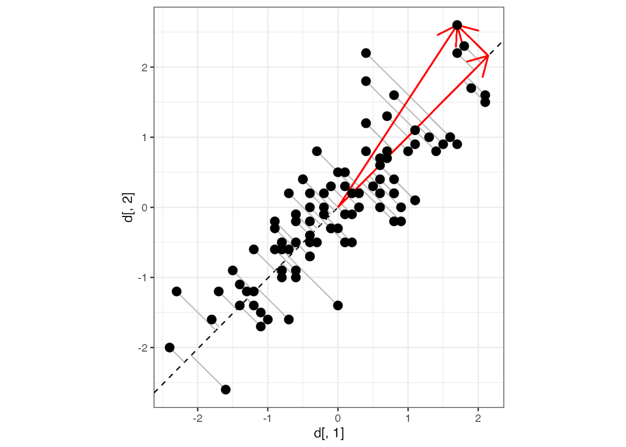

```r
set.seed(1234)
sig <- matrix(c(1,0.8,0.8,1), ncol = 2)
d <- rmvnorm(n = 100, mean = c(0,0), sigma = sig)
d <- round(scale(d),1)

eigen_vec <- c(eigen(cov(d))$vectors[1,1],
               eigen(cov(d))$vectors[2,1])

conv <- as.matrix(d) %*% eigen_vec
xx <- conv * eigen_vec[1] #垂線足のx座標
yy <- conv * eigen_vec[2] #垂線足のy座標
id <- which.max(d[,2])

d %>% as.data.frame() %>%
  ggplot(., aes(d[,1], d[,2])) +
  geom_abline(slope = eigen_vec[2] / eigen_vec[1], linetype = 2) +
  geom_segment(aes(x = xx, y = yy, xend = d[,1], yend = d[,2]), col = "gray") +
  geom_segment(aes(x = 0, y = 0, xend = d[id,1], yend = d[id,2]), arrow = arrow(), col = "red") +
  geom_segment(aes(x = xx[id], y = yy[id], xend = d[id,1], yend = d[id,2]), arrow = arrow(), col = "red") +
  geom_segment(aes(x = 0, y = 0, xend = xx[id], yend = yy[id]), arrow = arrow(), col = "red") +
  geom_point(size = 3) +
  coord_fixed(ratio = 1) +
  theme_bw()
```